# IODS course project

# Dimensionality Reduction Techniques

## Tasks

*Analysis.*

- Describe your work and results clearly.
- Assume the reader has an introductory course level understanding of writing and reading R code as well as statistical methods.
- Assume the reader has no previous knowledge of your data or the more advanced methods you are using.

*Preamble*

```r
# load packages
library(dplyr)
library(ggplot2)
library(GGally)
library(tidyr)
library(openxlsx)
library(corrplot)
library(knitr)
```

## Q1: Loading Dataset & graphical overview

```r
human <- read.xlsx("~/R/win-library/4.0/IODS-project/data/human.xlsx", rowNames = TRUE)
dim(human)
```

```
## [1] 155   8
```

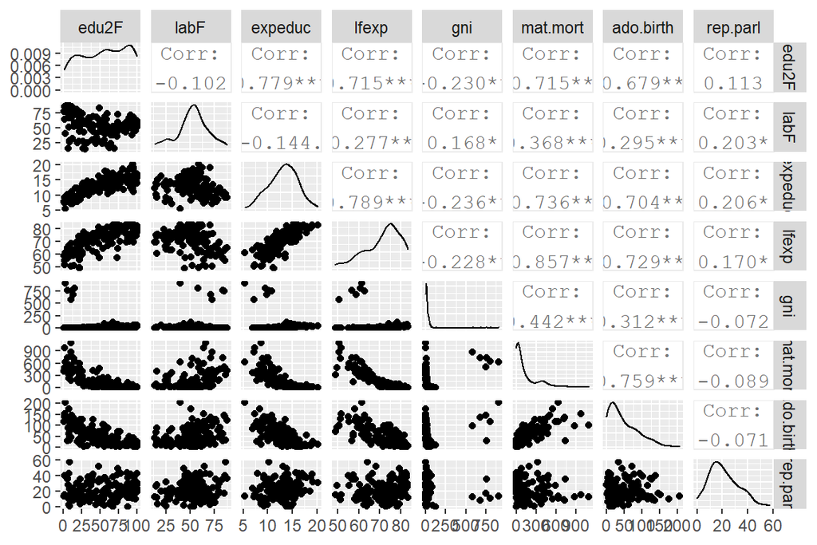

```r
ggpairs(human)
```

```r
# compute the correlation matrix and visualize it with corrplot
cor(human)
```

```
##                edu2F       labF    expeduc      lfexp         gni   mat.mort
## edu2F      1.0000000 -0.1020555  0.7787572  0.7150176 -0.22972064 -0.7152403
## labF      -0.1020555  1.0000000 -0.1440642 -0.2773393  0.16819986  0.3684019
## expeduc    0.7787572 -0.1440642  1.0000000  0.7894392 -0.23596897 -0.7357026
## lfexp      0.7150176 -0.2773393  0.7894392  1.0000000 -0.22772308 -0.8571684
## gni       -0.2297206  0.1681999 -0.2359690 -0.2277231  1.00000000  0.4416904
## mat.mort  -0.7152403  0.3684019 -0.7357026 -0.8571684  0.44169045  1.0000000
## ado.birth -0.6787028  0.2952703 -0.7035649 -0.7291774  0.31237593  0.7586615
## rep.parl   0.1129953  0.2025733  0.2060816  0.1700863 -0.07192042 -0.0894400
##            ado.birth    rep.parl
## edu2F     -0.6787028  0.11299529
## labF       0.2952703  0.20257328
## expeduc   -0.7035649  0.20608156
## lfexp     -0.7291774  0.17008631
## gni        0.3123759 -0.07192042
## mat.mort   0.7586615 -0.08944000
## ado.birth  1.0000000 -0.07087810
## rep.parl  -0.0708781  1.00000000
```

```r
summary(human)
```

```
##      edu2F             labF          expeduc          lfexp
##  Min.   :  0.90   Min.   :13.50   Min.   : 5.40   Min.   :49.00
##  1st Qu.: 27.15   1st Qu.:44.45   1st Qu.:11.25   1st Qu.:66.30
##  Median : 56.60   Median :53.50   Median :13.50   Median :74.20
##  Mean   : 55.37   Mean   :52.52   Mean   :13.18   Mean   :71.65
##  3rd Qu.: 85.15   3rd Qu.:61.90   3rd Qu.:15.20   3rd Qu.:77.25
##  Max.   :100.00   Max.   :88.10   Max.   :20.20   Max.   :83.50
##       gni             mat.mort        ado.birth         rep.parl
##  Min.   :  1.123   Min.   :   1.0   Min.   :  0.60   Min.   : 0.00
##  1st Qu.:  5.275   1st Qu.:  11.5   1st Qu.: 12.65   1st Qu.:12.40
##  Median : 13.054   Median :  49.0   Median : 33.60   Median :19.30
##  Mean   : 46.496   Mean   : 149.1   Mean   : 47.16   Mean   :20.91
##  3rd Qu.: 27.256   3rd Qu.: 190.0   3rd Qu.: 71.95   3rd Qu.:27.95
##  Max.   :908.000   Max.   :1100.0   Max.   :204.80   Max.   :57.50
```

The ‘human’ dataset originates from the United Nations Development Programme. It contains 155 observations with 8 variables. Please refer to [this link](http://hdr.undp.org/sites/default/files/hdr2015_technical_notes.pdf) for additional information. For a technical overview of the variables see information on [calculating the human development indices](http://hdr.undp.org/sites/default/files/hdr2015_technical_notes.pdf). We observe somewhat Gaussian distributions for Female labour force participation and expected years of education. The other variables have distributions that are heavily skewed. We observe high positive correlations between life expectancy at birth and expected education (0.79) as well as for Adolescent Birth Rate and Maternal Mortality Ratio (0.76). Low/negative is between Maternal Mortality Ratio and life expectancy at birth (-0.86) as well as between Adolescent Birth Rate and life expectancy at birth (-0.73)